# CokDegiskenliRegresyon slides

## Çok Değişkenli Regresyon

## Çok Değişken (Nitelik)

```python
eğitim_verisi.head()
```

|  | Konut_Boyutu(x1) | Garaj_Boyutu(x2) | Yapılma_Tarihi(x3) | Şömine_Adedi(x4) | Konut_Fiyat(y) |
| --- | --- | --- | --- | --- | --- |
| 0 | 8450 | 548 | 2003 | 0 | 208500 |
| 1 | 9600 | 460 | 1976 | 1 | 181500 |
| 2 | 11250 | 608 | 2001 | 1 | 223500 |
| 3 | 9550 | 642 | 1915 | 1 | 140000 |
| 4 | 14260 | 836 | 2000 | 1 | 250000 |

### Notasyon

**m** : Eğitim verisindeki örnek adedi

**x**: Girdi değişkenleri

**y**: Çıktı değişkeni

**$\theta$**: Katsayı ,Ağırlık

**h**: Hipotez

**(x, y)** – eğitim verisi

* Yeni notasyonlar :

$n$ : Nitelik adedi

$x^i$ : i. eğitim verisi için girdi değişkenleri (nitelikleri)

$x_j^i$ : i. eğitim verisi için j. değişkenin değeri

Hipotez : $ h_0(x)= \theta_0 + \theta_1*x $ -> Artık Değil!

Artık : $ h_0(x)= \theta_0 + \theta_1*x_1+ \theta_2*x_2 + \theta_3*x_3 +...+ \theta_n*x_n $

```python
y=eğitim_verisi[["Konut_Fiyat(y)"]];y.head()
```

|  | Konut_Fiyat(y) |
| --- | --- |
| 0 | 208500 |
| 1 | 181500 |
| 2 | 223500 |
| 3 | 140000 |
| 4 | 250000 |

```python
nitelik_listesi=eğitim_verisi.columns.tolist();nitelik_listesi.remove("Konut_Fiyat(y)");nitelik_listesi
```

```
['Konut_Boyutu(x1)',
 'Garaj_Boyutu(x2)',
 'Yapılma_Tarihi(x3)',
 'Şömine_Adedi(x4)']
```

```python
x=eğitim_verisi[nitelik_listesi];x.head(2)
```

|  | Konut_Boyutu(x1) | Garaj_Boyutu(x2) | Yapılma_Tarihi(x3) | Şömine_Adedi(x4) |
| --- | --- | --- | --- | --- |
| 0 | 8450 | 548 | 2003 | 0 |
| 1 | 9600 | 460 | 1976 | 1 |

```python
x.loc[0]
```

```
Konut_Boyutu(x1)      8450
Garaj_Boyutu(x2)       548
Yapılma_Tarihi(x3)    2003
Şömine_Adedi(x4)         0
Name: 0, dtype: int64
```

```python
theta0=50000;theta1=10;theta2=1.2;theta3=0.1;theta4=0.2
theta=pd.DataFrame([theta0,theta1,theta2,theta3,theta4],columns=["Katsayılar"])
```

```python
theta
```

|  | Katsayılar |
| --- | --- |
| 0 | 50000.0 |
| 1 | 10.0 |
| 2 | 1.2 |
| 3 | 0.1 |
| 4 | 0.2 |

```python
x0=[1]*x.shape[0]
```

```python
x["Yanlılık(x0)"]=x0
girdi_listesi=x.columns.tolist();girdi_listesi.remove("Yanlılık(x0)");girdi_listesi.insert(0,"Yanlılık(x0)")
```

```python
girdi_listesi
```

```
['Yanlılık(x0)',
 'Konut_Boyutu(x1)',
 'Garaj_Boyutu(x2)',
 'Yapılma_Tarihi(x3)',
 'Şömine_Adedi(x4)']
```

```python
h=pd.DataFrame(np.dot(x,theta),columns=["Tahmin(h)"])
```

```python
def tahmin(x,theta):
    h=pd.DataFrame(np.dot(x,theta),columns=["Tahmin(h)"])
    return h
```

```python
tahmin(x,theta).head(2)
```

|  | Tahmin(h) |
| --- | --- |
| 0 | 135357.9 |
| 1 | 146749.8 |

```python
y.head(2)
```

|  | Konut_Fiyat(y) |
| --- | --- |
| 0 | 208500 |
| 1 | 181500 |

$Bedel(J_{\theta})$:$ \begin{equation}\ 1/2m \sum_{i=1}^m (h_{\theta}(x^{(i)})-y^{(i)}))^2 \end{equation} $

```python
m=y.shape[0]
j=(1/(2*m))*np.sum(np.array(np.square(np.dot(x,theta)-y)))
```

```python
print("Bedel değeri:",j)
```

```
Bedel değeri: 6344618856.149989
```

$Artık(r^{(i)})= \begin{equation}\ h_{\theta}(x^{(i)})-y^{(i)} \end{equation} $

```python
r=pd.DataFrame((np.array(h)-np.array(y)),columns=["Artık(r)"]);r.head(2)
```

|  | Artık(r) |
| --- | --- |
| 0 | -73142.1 |
| 1 | -34750.2 |

$Dereceli(g)\ \ Azalım:$

Tekrarla: { \begin{equation}\ \theta_j := \theta_j-a*\frac{\partial J(\theta_0,\theta_1,...\theta_n)}{\partial \theta_j} \end{equation} }

Anlık olarak her j=0,...,n için hesaplanır.

\begin{equation}\ \theta_j := \theta_j-a*1/m \sum_{i=1}^m (h_\theta(x^{(i)})-y^{(i)}))*x^{(i)} \end{equation}

Bu yüzden $\theta_0$ iken derece alçalma fonksiyonu :

$ \theta_0 \ için \ x^{(i)}=1' dir$

\begin{equation}\ \theta_0-> \theta_0 := \theta_0-a*1/m \sum_{i=1}^m (h_\theta(x^{(i)})-y^{(i)})) \end{equation}

\begin{equation}\ \theta_1-> \theta_1 := \theta_1-a*1/m \sum_{i=1}^m (h_\theta(x^{(i)})-y^{(i)}))*x_1^{(i)} \end{equation}

\begin{equation}\ \theta_2-> \theta_2 := \theta_2-a*1/m \sum_{i=1}^m (h_\theta(x^{(i)})-y^{(i)}))*x_2^{(i)} \end{equation}

$ Öğrenme Hızı : a$

```python
a=np.power(1/10,8) ;   theta0=50000;  theta1=10;   theta2=1.2;  theta3=0.1;  theta4=0.2
```

```python
theta0= theta0 - a*(1/m)*np.sum(np.array(h)-np.array(y)) ; theta0
```

```
50000.0002498809
```

```python
theta1=theta1 - a*(1/m)*np.sum(np.multiply((np.array(h)-np.array(y)), x.iloc[:,1].values)) ;theta1
```

```
3846.8134472143056
```

```python
theta2=theta2 - a*(1/m)*np.sum(np.multiply((np.array(h)-np.array(y)), x.iloc[:,2].values));theta2
```

```
173.75550206503905
```

### Nitelik Normalleştirme

Benzer ölçekteki veriler ile çalışmanın bize faydaları olacaktır. Neden ?

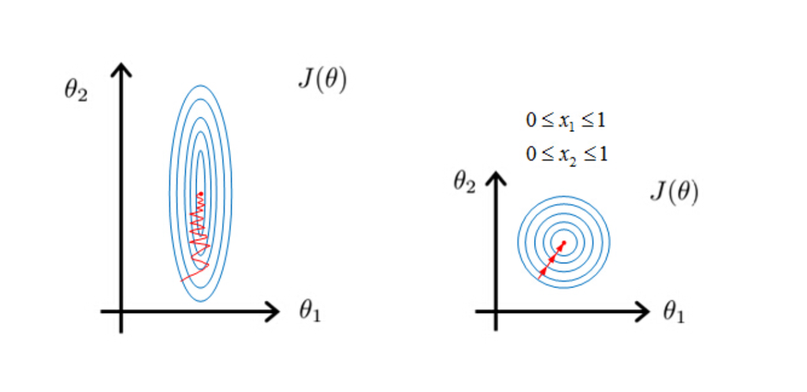

```python
x1=eğitim_verisi["Konut_Boyutu(x1)"]
```

```python
x2=eğitim_verisi["Şömine_Adedi(x4)"] #  Not1 :Aradaki farkın daha iyi gösterilmesi için  "Şömine_Adedi(x4)" x2 olarak kullanılmıştır
```

```python
print("X1 in minumum değeri" , x1.min(),"ve maksimum değeri" , x1.max())
```

```
X1 in minumum değeri 1300 ve maksimum değeri 215245
```

```python
print("X2 in minumum değeri" , x2.min(),"ve maksimum değeri" , x2.max())
```

```
X2 in minumum değeri 0 ve maksimum değeri 3
```

Nitelikleri benzer ölçeğe getireceğiz. Olmasını istediğimiz aralık : $ -1< x_i < 1 $ gibi olabilir.

#### Ortalama ile Normalleştirme

\begin{equation}\ x_i = \ \frac{ x_i -\mu_i }{ S_i} \end{equation}

* Notasyonlar :

$x_i$ : Nitelik (Girdi) Değeri

$\mu_i$ : $x_i$'nin Ortalaması

$S_i$ : $x_i$'nin Standart Sapması veya Maksimum Minumum Farkı

```python
x1_normal=(x1-x1.mean())/x1.std()
```

```python
x1_normal.loc[:2]
```

```
0   -0.207071
1   -0.091855
2    0.073455
Name: Konut_Boyutu(x1), dtype: float64
```

```python
print("X1_normal in minumum değeri" , x1_normal.min(),"ve maksimum değeri" , x1_normal.max())
```

```
X1_normal in minumum değeri -0.923412828397377 ve maksimum değeri 20.511245148264887
```

```python
x2_normal=(x2-x2.mean())/x2.std()
```

```python
x2_normal.loc[:2]
```

```
0   -0.950901
1    0.600289
2    0.600289
Name: Şömine_Adedi(x4), dtype: float64
```

```python
print("X2_normal in minumum değeri" , x2_normal.min(),"ve maksimum değeri" , x2_normal.max())
```

```
X2_normal in minumum değeri -0.9509006699369511 ve maksimum değeri 3.7026690890841056
```

```python
def normalizasyon(X):
    X_norm=pd.DataFrame(np.matrix(x)*0,columns=X.columns.tolist())

    for i in X.columns:
        if X[i].std()==0:
            X_norm[i]=1
        else:
            X_norm[i]=(X[i]-X[i].mean())/(X[i].std())
    return  X_norm
```

```python
normalizasyon(x).head(2)
```

|  | Yanlılık(x0) | Konut_Boyutu(x1) | Garaj_Boyutu(x2) | Yapılma_Tarihi(x3) | Şömine_Adedi(x4) |
| --- | --- | --- | --- | --- | --- |
| 0 | 1 | -0.207071 | 0.35088 | 1.050634 | -0.950901 |
| 1 | 1 | -0.091855 | -0.06071 | 0.156680 | 0.600289 |

### Dereceli Azaltma

\begin{equation}\ \theta_j := \theta_j-a*\frac{\partial J(\theta_0,\theta_1,...\theta_n)}{\partial \theta_j} \end{equation}

* Dereceli Azaltmanın doğru çalıştığından emin olmalıyız.

* Öğrenme hızını nasıl seçeceğiz ?

```python
# Tekrar sayısı : TS

def dereceli_azaltma(x, y, theta, a=0.1,TS=10 ):

    x_m=np.array(x) # X,y ve thetayı işlem kolaylığı için matrix haline getiriyoruz.

    y_m=np.array(y)


    m=y.shape[0] # Eğitim verisindeki örnek adedi ( boyut i, satırlar)

    n=x.shape[1] # Nitelik adedi   ( boyut j, sütünlar)

    J_history=[] # Oluşan Bedelleri burada toplayacağız
    J_history.append(bedel(x,y,theta))
    for s in range(TS):
        theta_m=np.array(theta)
        theta_s=theta_m
        for j in range(n):

            derece_= np.sum(np.multiply(np.array(np.array(x_m.dot(theta_m)-y_m)).T,x_m[:,j]))/m # Önce dereceyi hesaplıyoruz.
            theta_s[j]=theta_m[j]-a*derece_ # Sonra onu katsayıdan öğrenme hızıyla çarpıp çıkartıyoruz

        theta[theta.columns[0]]=theta_s # Bütün katsayıları bir anda güncelliyoruz.

        J_history.append(bedel(x,y,theta)) # Bedel fonskiyonu ile her bir denemedeki bedeli hesaplıyoruz.

    return  theta_m, J_history
```

```python
theta0=50000;theta1=10;theta2=1.2;theta3=0.1;theta4=0.2
theta=pd.DataFrame([theta0,theta1,theta2,theta3,theta4],columns=["Katsayılar"])
```

```python
t,j=dereceli_azaltma(x, y, theta, a=0.1,TS=50 )
```

```python
t # Yeni katsayılar
```

```
array([[180246.45747692],
       [  9012.03955045],
       [ 30446.72889549],
       [ 23486.60747387],
       [ 22908.16150077]])
```

```python
j[:5] # Bedelin değişimi , azalmasını istiyoruz
```

```
[11723293696.180288,
 9564969694.407377,
 7876120887.864886,
 6549535557.8585005,
 5503830273.220112]
```

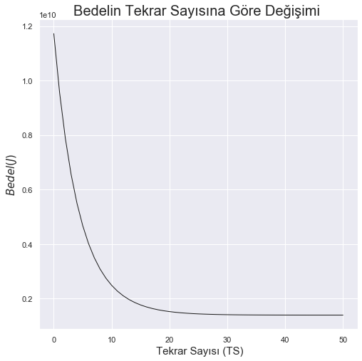

```python
cizdir()
```

```python
# Öğrenme Hızını Biraz Büyük Seciyoruz   a=10

theta0=50000; theta1=10 ; theta2=1.2 ;  theta3=0.1;theta4=0.2

theta=pd.DataFrame([theta0,theta1,theta2,theta3,theta4],columns=["Katsayılar"])

a=10

t,j=dereceli_azaltma(x, y, theta, a=a,TS=50 )

print("Öğrenme hızı",a)
print("Katsayılar" , t)
print("Bedelin ilk 10 tekrardaki değişimi", j[:10]) ;
```

```
Öğrenme hızı 10
Katsayılar [[-6.74738493e+52]
 [ 4.79676573e+59]
 [-2.22611038e+60]
 [-1.35070662e+60]
 [ 1.30896309e+61]]
Bedelin ilk 10 tekrardaki değişimi [11723293696.180288, 758234600145.991, 218538221002345.28, 1.551168580670321e+16, 4.993657195559304e+18, 1.0468663536131628e+21, 5.859873179589111e+22, 4.388309659084343e+25, 1.6747713709889662e+27, 1.0749153509292629e+30]
```

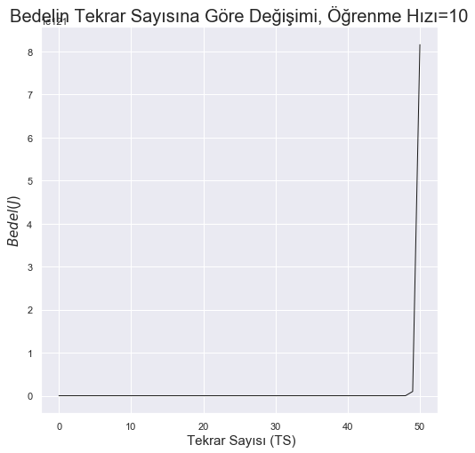

```python
cizdir()
```

```python
# Öğrenme Hızını Biraz Azaltalım z a=3

theta0=50000;theta1=10;theta2=1.2;theta3=0.1;theta4=0.2

theta=pd.DataFrame([theta0,theta1,theta2,theta3,theta4],columns=["Katsayılar"])

a=3 # ÖĞRENME HIZI

t,j=dereceli_azaltma(x, y, theta, a=a,TS=100  )
print("Öğrenme hızı",a)
print("Katsayılar" , t)
print("Bedelin ilk 10 tekrardaki değişimi", j[:10])
```

```
Öğrenme hızı 3
Katsayılar [[-1.65962333e+35]
 [-1.45979554e+37]
 [ 4.38811591e+36]
 [ 7.37023947e+35]
 [-2.56870575e+37]]
Bedelin ilk 10 tekrardaki değişimi [11723293696.180288, 40601805093.14357, 158117944187.64374, 618063238867.9841, 2751471629516.4526, 10787213692343.635, 42854291276274.875, 182068343715847.4, 737245581040563.2, 3073789563561455.0]
```

```python
bedel_df=pd.DataFrame(columns=["Bedel"])
bedel_df["Bedel"]=j;bedel_df.reset_index(inplace=True)
```

**Öğrenme hızını çok seçersek bedel azalmak yerine artar ve öğrenme gerçekleşmez.**

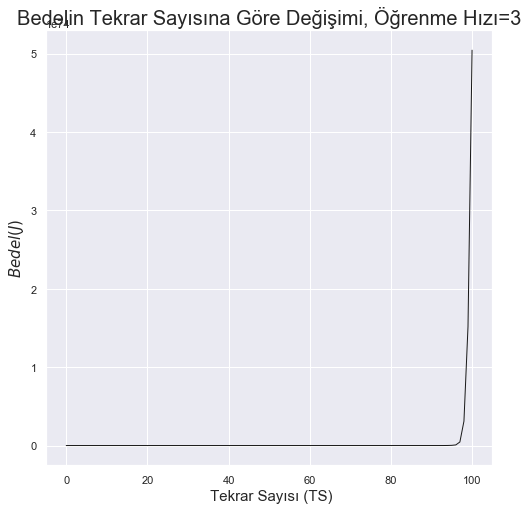

```python
cizdir()
```

```python
# İdeal bir Öğrenme Hızı seçtiğimizde  a=0.1

theta0=50000; theta1=10; theta2=1.2; theta3=0.1; theta4=0.2
theta=pd.DataFrame([theta0,theta1,theta2,theta3,theta4],columns=["Katsayılar"])

a=0.1 # ÖĞRENME HIZI

t,j=dereceli_azaltma(x, y, theta, a=a,TS=50 )
print("Öğrenme hızı",a)
print("Katsayılar" , t)
print("Bedelin ilk 10 tekrardaki değişimi", j[:3])
```

```
Öğrenme hızı 0.1
Katsayılar [[180246.45747692]
 [  9012.03955045]
 [ 30446.72889549]
 [ 23486.60747387]
 [ 22908.16150077]]
Bedelin ilk 10 tekrardaki değişimi [11723293696.180288, 9564969694.407377, 7876120887.864886]
```

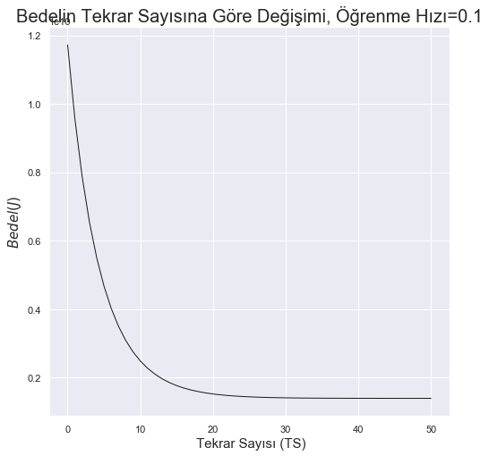

```python
cizdir()
```

```python
# Öğrenme hızını daha  az seçiyoruz.   a=0.01

theta0=50000;theta1=10;theta2=1.2;theta3=0.1;theta4=0.2
theta=pd.DataFrame([theta0,theta1,theta2,theta3,theta4],columns=["Katsayılar"])
a=0.01 ## ÖGRENME HIZI

t,j=dereceli_azaltma(x, y, theta, a=a,TS=50 )
print("Öğrenme hızı",a)
print("Katsayılar" , t)
print("Bedelin ilk 10 tekrardaki değişimi", j[:10])
```

```
Öğrenme hızı 0.01
Katsayılar [[101713.07805981]
 [  6704.5538882 ]
 [ 16859.9281618 ]
 [ 13960.09245497]
 [ 12573.23134236]]
Bedelin ilk 10 tekrardaki değişimi [11723293696.180288, 11493619410.28106, 11269331727.176506, 11050295850.215364, 10836380598.474733, 10627458303.257208, 10423404707.714226, 10224098869.497349, 10029423066.342447, 9839262704.494684]
```

**Öğrenme hızını az seçersek bedeli azaltmamız uzun sürer. Çok fazla tekrar yapmamız gerekir.**

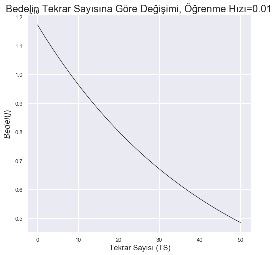

```python
cizdir()
```

### Nitelikler ve Polinom Regresyon

\begin{equation}\ h\theta(x) = \theta_0 + \theta_1*x_1(BinanınEni) + \theta_2*x_2(BinanınDerinliği) \end{equation}

\begin{equation}\ x = x_1(BinanınEni) *x_2(BinanınDerinliği) \end{equation}

\begin{equation}\ h\theta(x) = \theta_0 + \theta_1*x(BinanınBoyutu ) \end{equation}

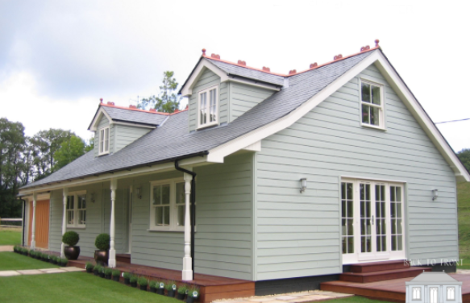

```python
BinaEni=[10,12,13,12,14,12,13]
BinaDerinliği=[10,11,13,17,16,13,11]
Konut_Fiyat=[200,300,400,500,600,390,350]
```

```python
y=pd.DataFrame(Konut_Fiyat,columns=["Konut_Fiyat(y)"]);y.head(2)
```

|  | Konut_Fiyat(y) |
| --- | --- |
| 0 | 200 |
| 1 | 300 |

```python
x=pd.DataFrame(BinaEni,columns=["BinaEni(x1)"])
x["BinaDerinliği(x2)"]=BinaDerinliği;x.head(3)
```

|  | BinaEni(x1) | BinaDerinliği(x2) |
| --- | --- | --- |
| 0 | 10 | 10 |
| 1 | 12 | 11 |
| 2 | 13 | 13 |

```python
x["BinaBoyutu(x3)"]=x["BinaEni(x1)"]*x["BinaDerinliği(x2)"];x.head(2)
```

|  | BinaEni(x1) | BinaDerinliği(x2) | BinaBoyutu(x3) |
| --- | --- | --- | --- |
| 0 | 10 | 10 | 100 |
| 1 | 12 | 11 | 132 |

```python
x["BinaEni^2(x4)"]=x["BinaEni(x1)"]**2
```

```python
x["BinaDerinliği^2(x5)"]=x["BinaDerinliği(x2)"]**2
```

```python
x["BinaBoyutu^3(x6)"]=x["BinaBoyutu(x3)"]**3
```

```python
eğitim_verisi=pd.concat([x,y.reindex(x.index)], axis=1)
```

```python
eğitim_verisi.head(2)
```

|  | BinaEni(x1) | BinaDerinliği(x2) | BinaBoyutu(x3) | BinaEni^2(x4) | BinaDerinliği^2(x5) | BinaBoyutu^3(x6) | Konut_Fiyat(y) |
| --- | --- | --- | --- | --- | --- | --- | --- |
| 0 | 10 | 10 | 100 | 100 | 100 | 1000000 | 200 |
| 1 | 12 | 11 | 132 | 144 | 121 | 2299968 | 300 |

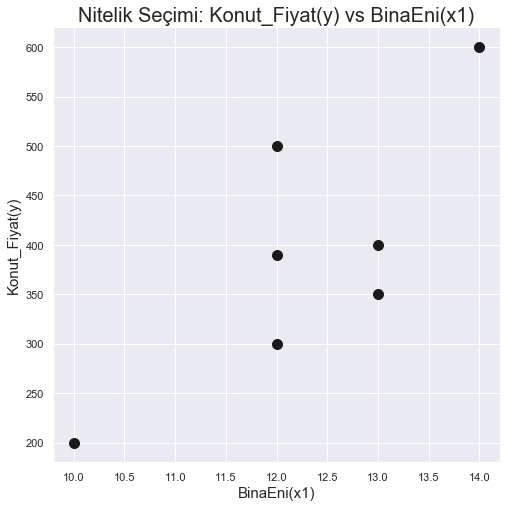

```python
cizdir()
```

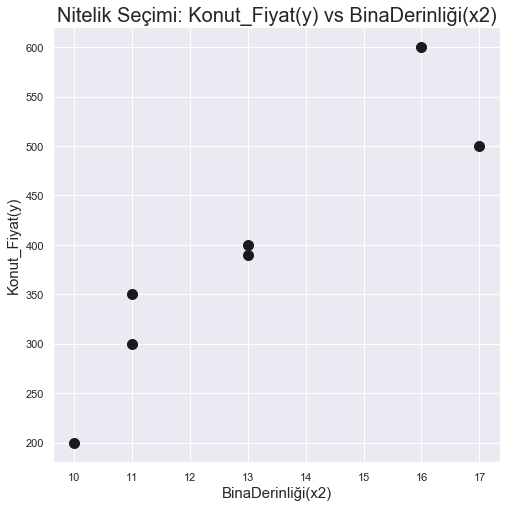

```python
cizdir()
```

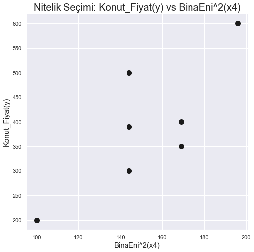

```python
cizdir()
```

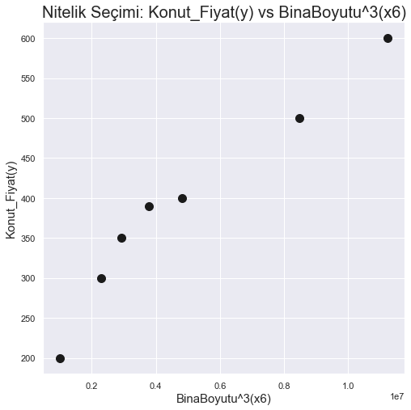

```python
cizdir()
```

\begin{equation}\ Seçim : h\theta(x) = \theta_0 + \theta_1*x(BinanınBoyutu ) \end{equation}

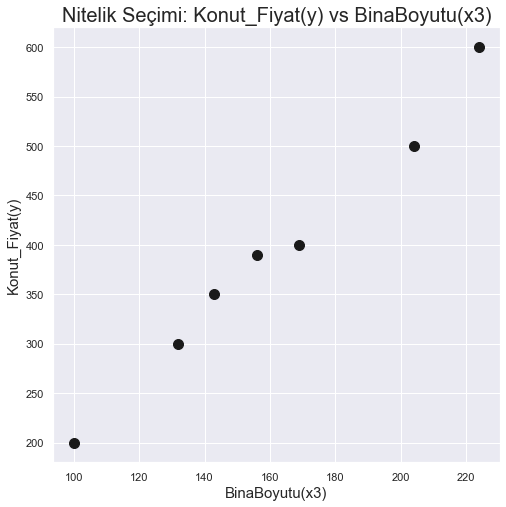

```python
cizdir()
```

### Normal Denklem Yoluyla Çözüm

Dereceli azaltma olmadan da regresyon katsayıları hesaplanabilir. Her bir katsayıyı tek tek bulmak yerine hepsini bir kere de bulabiliriz.

\begin{equation}\ \theta_j := \theta_j-a*\frac{\partial J(\theta_0,\theta_1,...\theta_n)}{\partial \theta_j} \end{equation}

İlk örneğimize dönelim

```python
eğitim_verisi=pd.read_csv("data/train.csv")
# Konut fiyatları için eğitim seti
eğitim_verisi.rename(columns={"Fireplaces":"Şömine_Adedi(x4)","YearBuilt":"Yapılma_Tarihi(x3)","GarageArea":"Garaj_Boyutu(x2)","LotArea":"Konut_Boyutu(x1)","SalePrice":"Konut_Fiyat(y)"},inplace=True)
eğitim_verisi=eğitim_verisi[["Konut_Boyutu(x1)","Garaj_Boyutu(x2)","Yapılma_Tarihi(x3)","Şömine_Adedi(x4)" ,"Konut_Fiyat(y)"]]
y=eğitim_verisi[["Konut_Fiyat(y)"]]
nitelik_listesi=eğitim_verisi.columns.tolist();nitelik_listesi.remove("Konut_Fiyat(y)");nitelik_listesi
x=eğitim_verisi[nitelik_listesi];x=girdi(x)
```

```python
y.head(2)
```

|  | Konut_Fiyat(y) |
| --- | --- |
| 0 | 208500 |
| 1 | 181500 |

```python
x.head(2)
```

|  | Yanlılık(x0) | Konut_Boyutu(x1) | Garaj_Boyutu(x2) | Yapılma_Tarihi(x3) | Şömine_Adedi(x4) |
| --- | --- | --- | --- | --- | --- |
| 0 | 1 | 8450 | 548 | 2003 | 0 |
| 1 | 1 | 9600 | 460 | 1976 | 1 |

\begin{equation}\ \theta=(X^TX)^{-1}X^Ty \end{equation}

```python
theta_yeni=np.dot(np.dot(np.linalg.inv(np.dot(x.T,x)),x.T),y) # Yukarıdaki formul ile hesaplarsak
```

```python
bedel(x,y,theta_yeni)
```

```
1392901096.5439003
```

```python
x_norm=normalizasyon(x)
theta0=50000;theta1=10;theta2=1.2;theta3=0.1;theta4=0.2
theta=pd.DataFrame([theta0,theta1,theta2,theta3,theta4],columns=["Katsayılar"])
a=0.1
t,j=dereceli_azaltma(x_norm, y, theta, a=a,TS=500)
print("Katsayılar" , t)
print("Bedelin ilk 10 tekrardaki değişimi", j[:10])
```

```
Katsayılar [[180921.19589041]
 [  8875.15877269]
 [ 30527.65077899]
 [ 23393.15030008]
 [ 23013.79512974]]
Bedelin ilk 10 tekrardaki değişimi [11723293696.180288, 9564969694.407377, 7876120887.864886, 6549535557.8585005, 5503830273.220112, 4676889145.521014, 4021050371.5349007, 3499556437.7670794, 3083922168.651796, 2751972519.843328]
```

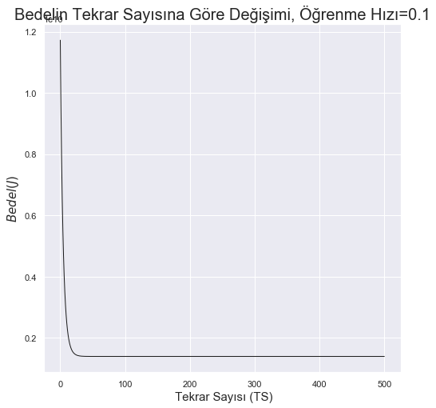

```python
plt.figure(figsize=(8,8))
title="Bedelin Tekrar Sayısına Göre Değişimi, Öğrenme Hızı="+str(a)
plt.title(title,fontsize="20")
plt.ylabel("$Bedel(J) $",fontsize=15)
plt.xlabel(" Tekrar Sayısı (TS)",fontsize=15)
plt.plot(bedel_df["index"],bedel_df["Bedel"], 'k-',linewidth=1,markersize=18)
plt.show()
```

```python
print("Normal Denklem Yolu ile Bedel:" ,bedel(x,y,theta_yeni) ,"Dereceli Azaltma 500 Tekrardan Sonra ise Bedel", j[-1])
```

```
Normal Denklem Yolu ile Bedel: 1392901096.5439003 Dereceli Azaltma 500 Tekrardan Sonra ise Bedel 1392901096.5439005
```

```python
theta_normal=pd.DataFrame(theta_yeni,columns=["Normal Denklem Katsayılar"]);theta_normal
```

|  | Normal Denklem Katsayılar |
| --- | --- |
| 0 | -1.444660e+06 |
| 1 | 8.891818e-01 |
| 2 | 1.427828e+02 |
| 3 | 7.745331e+02 |
| 4 | 3.569877e+04 |

Dereceli Azaltma

- Öğrenme Hızını iyi seçmek gerekir.

- Çok fazla tekrar gerektirir.

- Nitelik adedi(n) fazla bile olsa iyi çalışır

Normal Denklem

- Öğrenme Hızını seçmeye gerek yoktur.

- Tekrar gerektirmez.

- $(X^TX)^{-1}$ hesaplayabilmek gerekir. Bazen inverse alınması mümkün olmuyor.

- Nitelik adedi(n) fazla ise yavaş çalışır.

```python
np.linalg.inv(np.dot(x,x.T))
```

```
---------------------------------------------------------------------------
LinAlgError                               Traceback (most recent call last)
<ipython-input-353-11876ea0240e> in <module>
----> 1 np.linalg.inv(np.dot(x,x.T))

~\AppData\Local\Continuum\anaconda3\lib\site-packages\numpy\linalg\linalg.py in inv(a)
    549     signature = 'D->D' if isComplexType(t) else 'd->d'
    550     extobj = get_linalg_error_extobj(_raise_linalgerror_singular)
--> 551     ainv = _umath_linalg.inv(a, signature=signature, extobj=extobj)
    552     return wrap(ainv.astype(result_t, copy=False))
    553

~\AppData\Local\Continuum\anaconda3\lib\site-packages\numpy\linalg\linalg.py in _raise_linalgerror_singular(err, flag)
     95
     96 def _raise_linalgerror_singular(err, flag):
---> 97     raise LinAlgError("Singular matrix")
     98
     99 def _raise_linalgerror_nonposdef(err, flag):

LinAlgError: Singular matrix
```

Eğer yukarıdaki gibi bir hata alıyorsak . Bu matriks'in tekil olduğunu gösterir.

Bu durumlarda yapılması gereken birbirine bağımlı olan girdilerin azaltılması veyahut düzenlileştirme (regularization) yapmaktır.

```python
print("Sorularınız ?")
```

```
Sorularınız ?
```

```python
print("Teşekkürler...")
```

```
Teşekkürler...
```